# VAST Challenge 2021: Mini Challenge 1

Answers to Mini Challenge 1

Lim Jin Ru (Alethea) true  
07-23-2021

# Overview

This assignment is based on [**VAST Challenge 2021**](https://vast-challenge.github.io/2021/). The selected challenge topic for this assignment is [**Mini-Challenge 1**](https://vast-challenge.github.io/2021/MC1.html).

In the roughly twenty years that Tethys-based GAStech has been operating a natural gas production site in the island country of Kronos, it has produced remarkable profits and developed strong relationships with the government of Kronos. However, GAStech has not been as successful in demonstrating environmental stewardship.

In January 2014, the leaders of GAStech are celebrating their new-found fortune as a result of the initial public offering of their very successful company. In the midst of this celebration, several employees of GAStech go missing. An organization known as the Protectors of Kronos (POK) is suspected in the disappearance.

The Protectors of Kronos (POK) is a political activist movement stemmed from concerns about contamination from drilling at the Tiskele Bend gas fields. An international agency has tested water from the Tiskele River both upstream and downstream of the Tiskele Bend gas fields and confirmed that the presence of contaminants is consistent with pollution from Hyper Acidic Substrate Removal, a gas drilling technique employed by GAStech at the Tiskele Bend fields and these test results have also been published in several international journals.

My role is to use visual analytics to help law enforcement from Kronos and Tethys discover the relationships among the people and organizations.

# Background

Mini-Challenge 1 looks at the relationships and conditions that led up to the kidnapping. As an analyst, I’d be analysing a set of current and historical news reports, resumes of numerous GAStech employees and email headers from two weeks of internal GAStech company email to identify the complex relationships among all of these people and organizations.

# Literature Review, Objective and Motivation

In the literature review conducted of the 2014 VAST Challenge submissions covering the same crime case but with different questions, it was observed that many of the visualizations were quite informative and had their own strengths but there were some limitations or areas to improve as well.

Some areas that can be further improved on:

- Unidirectional tree diagrams were used to display relationships, but such diagrams lack the ability to show the dynamics of how multiple parties act as connectors of the various organizations/people
- Cluttered network diagrams with labels obscured by arrows
- Some of the network diagrams for emails between GAStech employees were not easy to visualize some embedded relationships (e.g. relationships within the department)

The proposed visualizations will attempt to overcome some of these limitations.

The participants used a variety of tools for their visualizations. For this assignment, the approach will be to utilize R programming solely as there are numerous visualization packages available in the R environment with useful functions and great adaptability. There are also many new packages constantly being pushed out in the R community. For this assignment, some of the newer R packages will also be explored and applied, including [**corporaexplorer**](https://cran.r-project.org/web/packages/corporaexplorer/index.html) published in 2021 and [**LDAvis**](https://cran.r-project.org/web/packages/LDAvis/index.html) published in 2015.

# Data Preparation

Data extraction, wrangling and data preparation were performed with R, primarily with tidyverse methods.

# Answers

**Qn: Characterize the news data sources provided. Which are primary sources and which are derivative sources? What are the relationships between the primary and derivative sources?**

To determine whether a news article is a primary or derivative source, a few visualisations would be used.

There are many characteristics that differentiate a primary and derivative source. A derivative source is any record that relies on other records for its information.

As derivative sources are second-hand account of events, they will cover information from the primary source, often providing additional analysis and interpretation. A correlation analysis of documents published by the news companies can help give us clues in the primary and derivative source relationships.

First, the correlation is set very low to allow us to explore the overall correlation between all the news sources of the different companies.

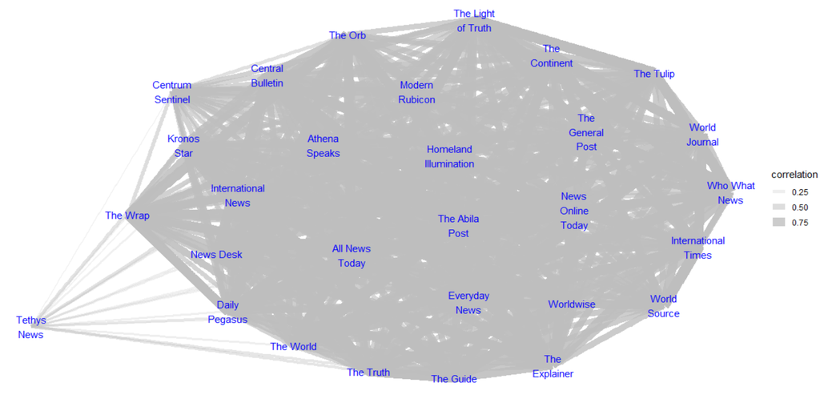

Tethys News is an outlier and needed a closer inspection for analysis.

A corpus exploration tool created from ‘corporaexplorer’ package in R was used. Tethys News’ articles have an update timestamp instead of just a publication date which suggests that their reporting are quite recent/close to the event. News that are written or made during or close to the time of the event is a characteristic of a primary source. Hence, Tethys News is likely to be a primary source.

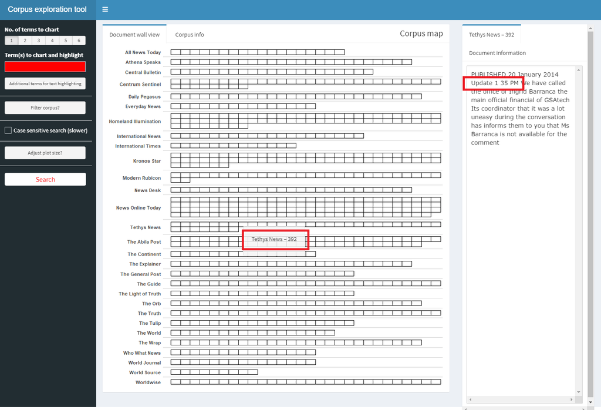

A high correlation of the news companies suggests that that the articles between the two companies are highly similar and that they may either both be derivative sources as they analyse and interpret each other’s work or that one is a primary source and the other is a derivative source as the latter aims to analyse and interpret the primary source, hence referencing a substantial amount of content from the primary source to facilitate analysis/interpretation. A correlation of 0.70 is selected to evaluate the relationships.

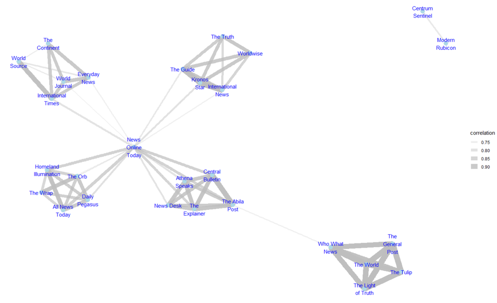

A number of clusters were formed with Centrum Sentinel and Modern Rubicon being quite far from the group, suggesting that they have higher likelihood of being of a primary source.

For the others with high correlation with each other, they are likely to be derivative sources.

For instance, Athena Speaks and Central Bulletin have a correlation of more than 0.8. This suggests that their news articles are highly similar.

The corpus exploration tool is used to examine the articles in two news companies. To allow a focus on a common topic, the corpus filter setting is set to include “kidnap—1”. This phrase will prompt the corporaexplorer to keep only articles with the word “kidnap” appearing at least once.

A comparison between Athena Speaks – 140 article and Central Bulletin – 673 article shows that their articles’ content are almost identical with just a paraphrasing of the text, suggesting that they are likely both derivative sources of another source or a record of each other.

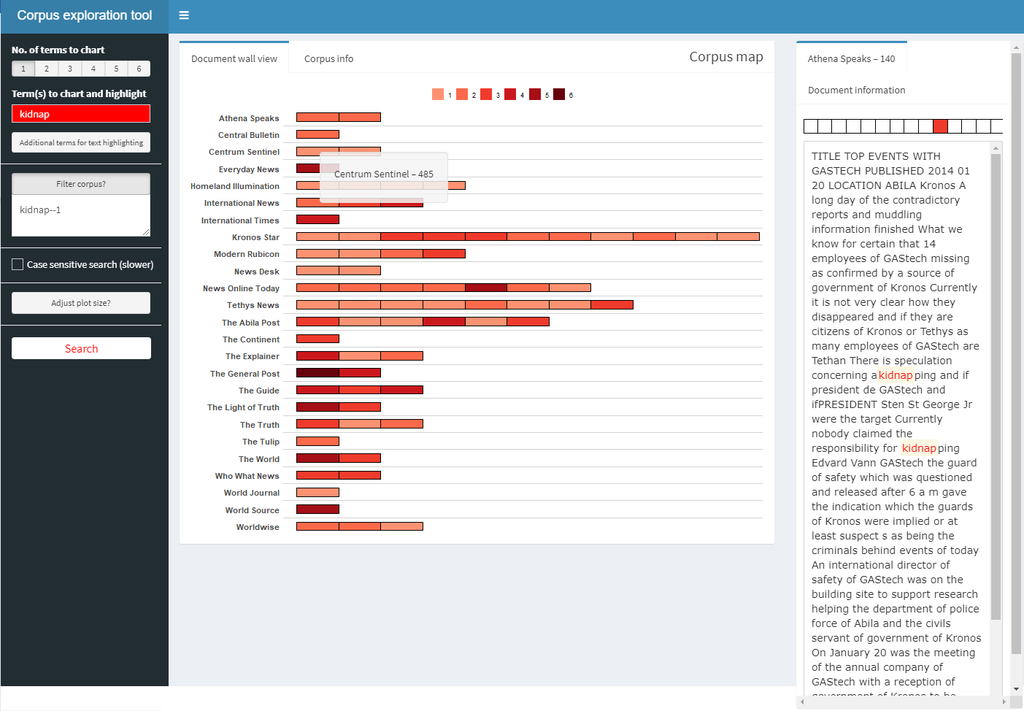